# Hierarchy Experiment: Preprocessing

Bodo Winter (statistical analysis)

7/17/2019

## Introduction

This is the statistical analysis of our “hierarchy experiment”, a replication-extension of Schubert’s (2005) study which associates vertical positions with power. The present study includes the added dimension of gender.

This script does all the preprocessing and gets the data in shape for the analysis.

## Preprocessing

Load stuff:

```r
# Packages:

library(tidyverse)

# Data:

power <- read_csv('data/hierarchy_experiment.csv')

# ggplot2 theme:

source('timo_theme.R')
```

Get rid of unwanted columns:

```r
power <- power %>%
  select(-(Session:ExperimentVersion),
         -Group, -RandomSeed,
         -(RandomSeed:Block),
         -(list1:list9),
         -ComprehensionQuestion.RESP,
         -ComprehensionQuestion.RT,
         -(MainConditionTable:MainList),
         -MainQuestion.RTTime,
         -MainScreen.RTTime,
         -(PracticeDisplayTime:Procedure),
         -(QuestionDisplayTime:TopProfession))
```

Get rid of practice trials:

```r
power <- power %>%
  filter(!is.na(MainScreen.RESP))
```

Rename columns:

```r
power <- power %>%
  rename(Task = ExperimentName,
         Subj = Subject,
         SubjGender = Gender,
         BottomProf = Bottomprofession,
         Comp.RESP = MainQuestion.RESP,
         Comp.RT = MainQuestion.RT,
         Country = HomeCountry,
         Language = NativeLanguage,
         GenderCond = GenderCondition,
         HierarchyCond = HierarchyCondition,
         Resp = MainScreen.RESP,
         RT = MainScreen.RT)
```

Rename content of all columns that contain responses:

```r
# Define helper function that transforms "{UPARROW}" to "up":

up_function <- function(x) ifelse(x == '{UPARROW}',
                                  'up', 'down')

# Use this function to get the up responses:

power <- power %>%
  mutate(Comp.RESP = up_function(Comp.RESP),
         Resp = up_function(Resp))

# Get rid of the function again:

rm(up_function)
```

Rename task column according to the following bits:

- A = which one is more powerful?
- B = which one is less powerful?

```r
# Define helper function:

power <- power %>%
  mutate(Task = ifelse(Task == 'professions_englishA',
                       'powerful', 'powerless'))
```

Create a unique identifier for each subject:

```r
power <- power %>%
  mutate(Subj = gl(nrow(power) / 128, 128))
```

Log transform RTs:

```r
power <- power %>%
  mutate(LogRT = log(RT),
         LogComp.RT = ifelse(Comp.RT != 0, log(Comp.RT), NA))
```

Exclude non-native speakers:

```r
power <- power %>%
    filter(str_detect(Language, '(e|E)nglish'),
        Country != 'Hong Kong',
        Country != 'Thailand')
```

Get rid of those columns (not needed now anymore):

```r
power <- power %>%
  select(-Language, -Country)
```

## Processing comprehension questions

Find correct repsonses to female question:

```r
# Define logical vectors with correct responses to female question:

# Up:

with(power,
    female_up <<- Question == 'Was the female at the top or bottom?')

with(power,
    female_up <<- female_up & GenderCond == 'FemaleTop' & Comp.RESP == 'up')

# Down:

with(power,
    female_down <<- Question == 'Was the female at the top or bottom?')

with(power,
    female_down <<- female_down & GenderCond == 'MaleTop' & Comp.RESP == 'down')

# Combine:

female_corr <- female_up | female_down

# Define logical vectors with correct repsonses to male question:

# Up:

with(power,
    male_up <<- Question == 'Was the male at the top or bottom?')

with(power,
    male_up <<- male_up & GenderCond == 'MaleTop' & Comp.RESP == 'up')

# Down:

with(power,
    male_down <<- Question == 'Was the male at the top or bottom?')

with(power,
    male_down <<- male_down & GenderCond == 'FemaleTop' & Comp.RESP == 'down')

# Combine:

male_corr <- male_up | male_down
```

Combine and attach to data frame:

```r
comp_corrects <- female_corr | male_corr
power$Comp.ACC <- comp_corrects
```

Clean up the helper vectors from my work space:

```r
rm(comp_corrects, male_corr,
   female_corr, male_up, male_down,
   female_up, female_down)
```

Get a dataframe of only the comprehension question responses:

```r
comps <- power %>%
    filter(!is.na(Comp.ACC))
```

Check accuracies per subject:

```r
# Create tibble with averages:

comp_avgs <- comps %>% group_by(Subj) %>%
  summarize(CompACC = mean(Comp.ACC)) %>%
    print(n = length(unique(power$Subj))) %>%
  arrange(CompACC)
```

```
## # A tibble: 63 x 2
##    Subj  CompACC
##    <fct>   <dbl>
##  1 1       1
##  2 2       1
##  3 3       0.917
##  4 4       1
##  5 5       0.917
##  6 6       1
##  7 7       0.958
##  8 8       0.958
##  9 9       1
## 10 10      1
## 11 11      1
## 12 12      0.958
```

[output cut: 51 more lines]

```r
#  Print the tibble:

comp_avgs %>%  print(n = Inf)
```

```
## # A tibble: 63 x 2
##    Subj  CompACC
##    <fct>   <dbl>
##  1 23      0.75
##  2 31      0.792
##  3 38      0.792
##  4 19      0.833
##  5 37      0.833
##  6 16      0.875
##  7 17      0.875
##  8 18      0.875
##  9 32      0.875
## 10 49      0.875
## 11 50      0.875
## 12 54      0.875
```

[output cut: 51 more lines]

Subject 23 performed with 75% accuracy, and subjects 31 and 38 performed with 79% accuracy. Everybody else is above 80% correct on the comprehension questions.

Check accuracies by nature of question:

```r
comps %>% group_by(GenderCond, Comp.RESP) %>%
    summarize(ACC = mean(Comp.ACC))
```

```
## # A tibble: 4 x 3
## # Groups:   GenderCond [2]
##   GenderCond Comp.RESP   ACC
##   <chr>      <chr>     <dbl>
## 1 FemaleTop  down      0.941
## 2 FemaleTop  up        0.957
## 3 MaleTop    down      0.930
## 4 MaleTop    up        0.946
```

There does not seem to be much of a difference between conditions, and certainly not even remotely an indication that there’s an interaction.

Now we can get rid of the question and question RT stuff:

```r
power <- power %>%
  select(-Comp.RESP, -Comp.RT, -Question, -Comp.ACC)
```

## Trial-accuracy:

In this section we look at the accuracy by trial — this is different from the accuracy for the comprehension question.

First, define helper vectors: logical vectors with information about what is or isn’t accurate.

```r
# For the "powerful" task:

with(power,
     powerful_correct <<- Task == 'powerful' &
       Resp == 'up' &
       HierarchyCond == 'TopPower')

with(power,
     powerful_correct <<- powerful_correct |
       Task == 'powerful' &
       Resp == 'down' &
       HierarchyCond == 'BottomPower')

# For the "powerless" task:

with(power,
     powerless_correct <<- Task == 'powerless' &
       Resp == 'down' &
       HierarchyCond == 'TopPower')

with(power,
     powerless_correct <<- powerless_correct |
       Task == 'powerless' &
       Resp == 'up' & HierarchyCond == 'BottomPower')
```

Add this to the dataframe as an accuracy column:

```r
power$ACC <- powerful_correct | powerless_correct
```

Clean up the helper vectors:

```r
rm(powerful_correct, powerless_correct)
```

Get the accuracy averages per subject:

```r
ACC_avgs <- power %>% group_by(Subj) %>%
  summarize(ACC = mean(ACC)) %>%
  arrange(ACC)

ACC_avgs %>% print(n = Inf)
```

```
## # A tibble: 63 x 2
##    Subj    ACC
##    <fct> <dbl>
##  1 23    0.516
##  2 55    0.789
##  3 31    0.797
##  4 70    0.828
##  5 27    0.867
##  6 12    0.883
##  7 24    0.891
##  8 57    0.891
##  9 3     0.898
## 10 30    0.898
## 11 33    0.898
## 12 36    0.898
```

[output cut: 51 more lines]

Subject 23 is at chance! Most other subjects are above 80% or close to 80%.

## Look at response times:

Make a graph of the RT distribution:

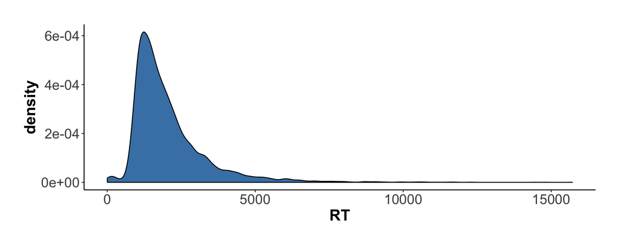

```r
power %>% ggplot(aes(x = RT)) +
  geom_density(fill = 'steelblue') +
  theme_bham_stats
```

Compute RT by subject:

```r
RT_avgs <- power %>% group_by(Subj) %>%
    summarize(RT = mean(RT)) %>% print(n = Inf)
```

```
## # A tibble: 63 x 2
##    Subj     RT
##    <fct> <dbl>
##  1 1     1575.
##  2 2     2729.
##  3 3     2627.
##  4 4     3270.
##  5 5     2339.
##  6 6     3302.
##  7 7     1942.
##  8 8     2624.
##  9 9     1681.
## 10 10    2033
## 11 11    2479.
## 12 12    1322.
```

[output cut: 51 more lines]

Subject 23 is weird. This subject has <500ms responses, which seems to be impossible given that two words have to be read on the same screen.

## Exclude obviously misbehaving subjects

Let’s merge this with the by-subject accuracies:

```r
subj_avgs <- left_join(comp_avgs, RT_avgs) %>% left_join(ACC_avgs)
```

So, there are definite (theory-independent) reasons to exclude subject 23, who had impossibly low RTs and was performing at chance.

Exclude this subject:

```r
power <- power %>%
  filter(Subj != 23)
```

## Exclude inaccurate trials

How many inaccurates are there?

```r
# Raw numbers of inaccurates and accurates:

table(power$ACC)
```

```
##
## FALSE  TRUE
##   494  7442
```

```r
# Percentage:

str_c(round((1 - (sum(power$ACC) / nrow(power))) * 100, 1), '%')
```

```
## [1] "6.2%"
```

Exclude inaccurates:

```r
power <- filter(power, ACC)

# Check:

nrow(power)
```

```
## [1] 7442
```

The number matches the number of “TRUE” responses above.

## Exclude very slow responses (by-subject):

Loop through the dataset by participants:

```r
# Vextor of subjects to loop through:

these_subs <- unique(power$Subj)

# Initialize empty data frame:

new_df <- c()

# Standard deviation cut-off value:

sd_fac <- 2

# Loop through subjects:

for (i in seq_along(these_subs)) {
  # Extract that subject:

    this_df <- filter(power, Subj == these_subs[i])

    # Save the log RTs of that subject:

    rts <- this_df$LogRT

    # Compute upper and lower bound for that subject:

    UB <- mean(rts) + sd_fac * sd(rts)
    LB <- mean(rts) - sd_fac * sd(rts)

    # Get only those that are within bounds:

    this_df <- filter(this_df,
                      !(rts > UB | rts < LB))

    # Bind to empty data frame:

    new_df <- rbind(new_df, this_df)
}

# Remove helper objects:

rm(i, LB, rts, these_subs, this_df, UB)
```

How many exclusions? Compare the size of the new data frame to the one of the old one:

```r
# Raw numbers:

nrow(new_df)
```

```
## [1] 7159
```

```r
nrow(power)
```

```
## [1] 7442
```

```r
# Percentage:

str_c(round((1 - (nrow(new_df) / nrow(power))) * 100, 1), '%')
```

```
## [1] "3.8%"
```

Plot the distribution again:

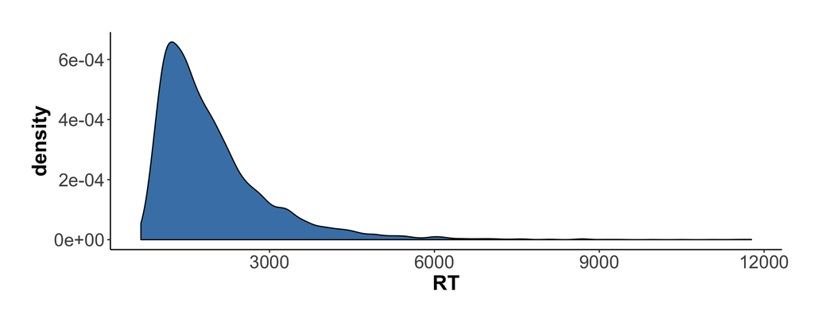

```r
new_df %>% ggplot(aes(x = RT)) +
  geom_density(fill = 'steelblue') +
  theme_bham_stats
```

What is the 95% quantile of this distribution?

```r
quantile(new_df$RT, 0.95)
```

```
##    95%
## 3949.1
```

Take this as a cut-off value:

```r
new_df <- filter(new_df, RT < quantile(RT, 0.95))
```

Plot the distribution again:

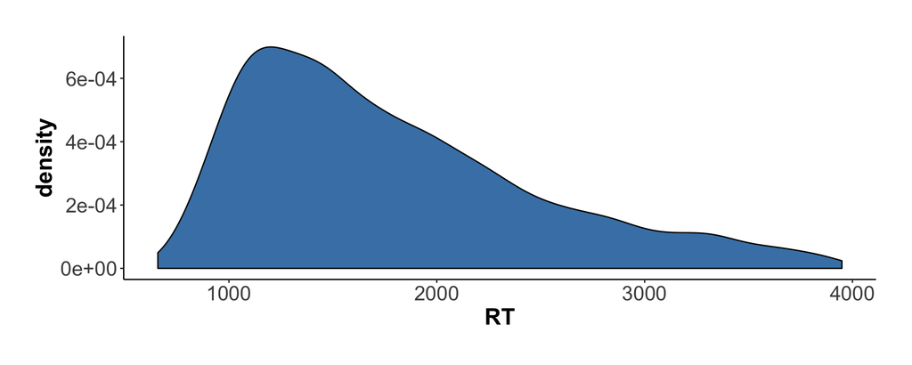

```r
new_df %>% ggplot(aes(x = RT)) +
  geom_density(fill = 'steelblue') +
  theme_bham_stats
```

Compare this to the log-transformed distribution:

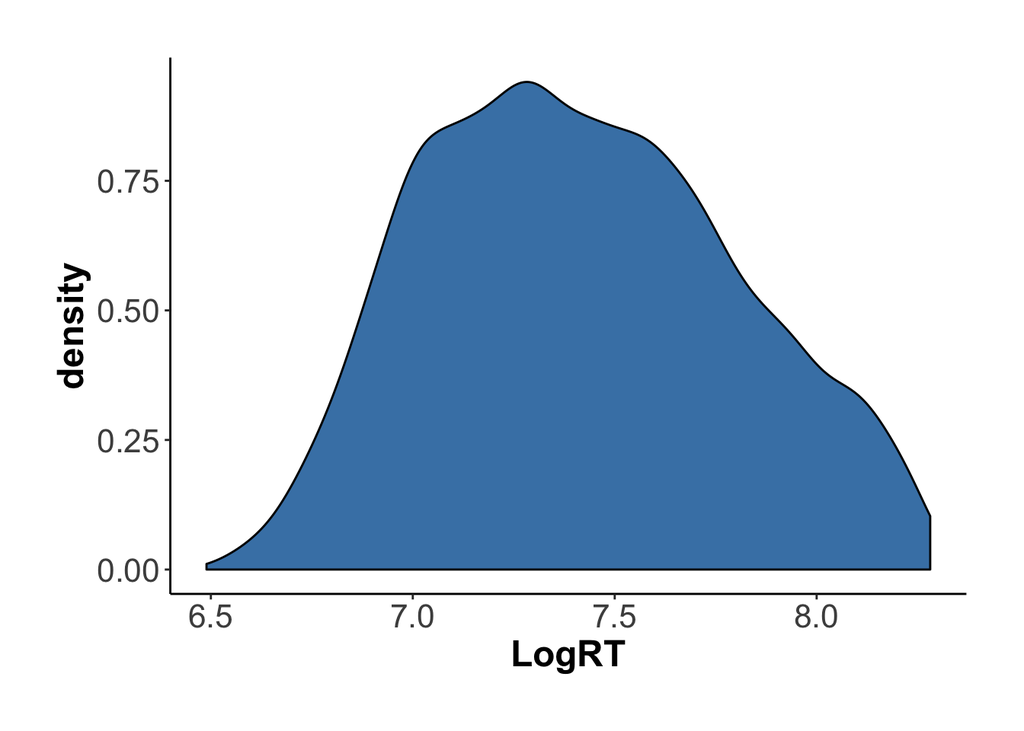

```r
new_df %>% ggplot(aes(x = LogRT)) +
  geom_density(fill = 'steelblue') +
  theme_bham_stats
```

Override the original power data frame with this new one:

```r
power <- new_df
```

## Create additional condition identifiers

Create an identifier that matches which gender is associated with power (e.g., “female doctor” = female powerful, “male doctor” = “male powerful”).

```r
# Initialize column with 'female=powerful':

power$GenderPower <- 'female=powerful'

# Change those for which 'male=powerful':

power[power$HierarchyCond == 'TopPower' & power$GenderCond == 'MaleTop', ]$GenderPower <- 'male=powerful'

power[power$HierarchyCond == 'BottomPower' & power$GenderCond == 'FemaleTop', ]$GenderPower <- 'male=powerful'
```

Finally, create a “double match” variable, which follows the gender stereotype (men = more powerful) as well as the hierarchy condition, that is, male, powerful and on top.

```r
# Initialize empty column:

power$DoubleMatch <- 'no match'

# Override the correct ones:

power[power$HierarchyCond == 'TopPower' & power$GenderCond == 'MaleTop', ]$DoubleMatch <- 'male powerful on top'
```

Whether the picked gender is female or male:

```r
# Initialize column with 'female':

power$PickedGender <- 'female'

# Take the ones where the 'male' was picked:

power[power$Task == 'powerful' & power$HierarchyCond == 'TopPower' & power$GenderCond == 'MaleTop', ]$PickedGender <- 'male'

power[power$Task == 'powerful' & power$HierarchyCond == 'BottomPower' & power$GenderCond == 'FemaleTop', ]$PickedGender <- 'male'

power[power$Task == 'powerless' & power$HierarchyCond == 'BottomPower' & power$GenderCond == 'FemaleTop', ]$PickedGender <- 'male'

power[power$Task == 'powerless' & power$HierarchyCond == 'TopPower' & power$GenderCond == 'MaleTop', ]$PickedGender <- 'male'
```

## Save file:

Save the cleaned file outside of R:

```r
write_csv(power,
          'data/hierarchy_experiment_cleaned.csv')
```

This completes this script.